# Fish Reproduction and Energy Budget in ZooMSS

### Size Spectra

```r
# Abundance size spectrum
p_abund <- plotSizeSpectra(mdl_constant, by = "abundance", n_years = 500) +
  ggtitle("Abundance Size Spectrum")
```

```
#> Averaging final 500 years (2500 saved time steps with isave = 2) of abundance from 5000 total saved time steps.
```

```r
# Biomass size spectrum
p_biom <- plotSizeSpectra(mdl_constant, by = "biomass", n_years = 500) +
  ggtitle("Biomass Size Spectrum")
```

```
#> Averaging final 500 years (2500 saved time steps with isave = 2) of biomass from 5000 total saved time steps.
```

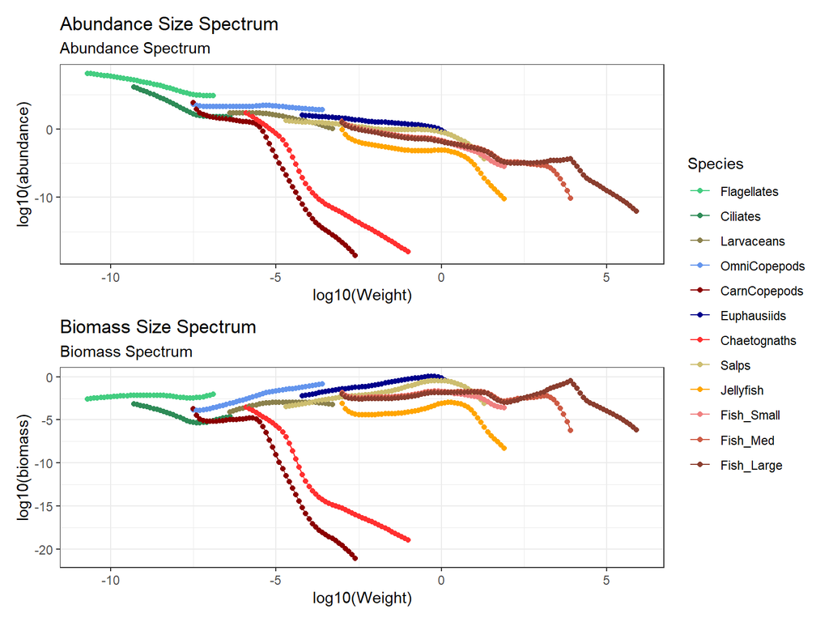

```r
wrap_plots(p_abund, p_biom, ncol = 1, guides = "collect")
```

## Part 2: Seasonal Environmental Forcing

Now let’s compare with seasonal environmental conditions to see how reproduction responds to environmental variability. We use the same base chlorophyll (1 mg m⁻³) but with seasonal variation, run for 1000 years.

```r
# Create seasonal environmental conditions
env_seasonal <- createEnviroData(
  n_years = 1000,
  dt = 0.1,
  base_sst = 15,
  base_chl = 1.0,
  seasonal = TRUE,
  sst_amplitude = 4,
  chl_amplitude = 0.5
)

env_seasonal_params <- createInputParams(
  time = env_seasonal$time,
  sst = env_seasonal$sst,
  chl = env_seasonal$chl
)
```

```
#> ZooMSS input parameters created:
#> - Time points: 10001 (time values provided)
#> - Time steps: 10000 (intervals to simulate)
#> - Time range: 0 to 1000 years
#> - dt = 0.1 years
#> - SST range: 11.2 to 18.8 deg C
#> - Chlorophyll range: 0.52 to 1.48 mg/m^3
```

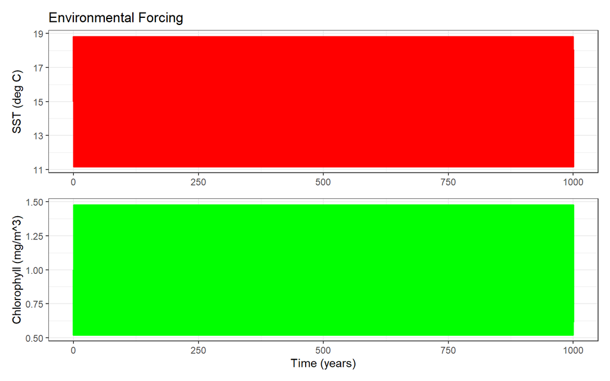

```r
# Plot the seasonal environment
plotEnvironment(env_seasonal_params)
```

```r
# Run or load from cache
mdl_seasonal <- run_or_load("mdl_seasonal_1000yr", env_seasonal_params, Groups, isave = 2, cache_dir = cache_dir)
```

### Comparing Constant vs Seasonal: Biomass

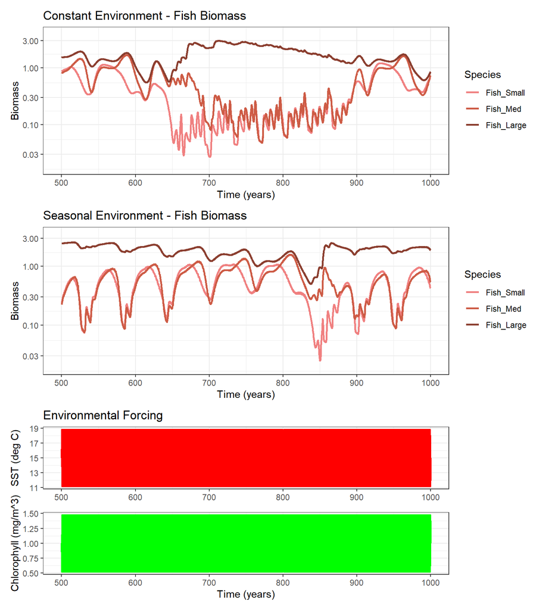

```r
# Constant environment biomass - focus on years 500-1000
p_const <- plotTimeSeries(mdl_constant, by = "biomass",
                          species = c("Fish_Small", "Fish_Med", "Fish_Large"),
                          transform = "log10") +
  ggtitle("Constant Environment - Fish Biomass") +
  xlim(500, 1000)

# Seasonal environment biomass
p_seas <- plotTimeSeries(mdl_seasonal, by = "biomass",
                         species = c("Fish_Small", "Fish_Med", "Fish_Large"),
                         transform = "log10") +
  ggtitle("Seasonal Environment - Fish Biomass") +
  xlim(500, 1000)

# Show the seasonal forcing for context
p_env <- plotEnvironment(env_seasonal_params) & xlim(500, 1000)

wrap_plots(p_const, p_seas, p_env, ncol = 1, heights = c(1, 1, 1))
```

### Comparing Constant vs Seasonal: Reproduction

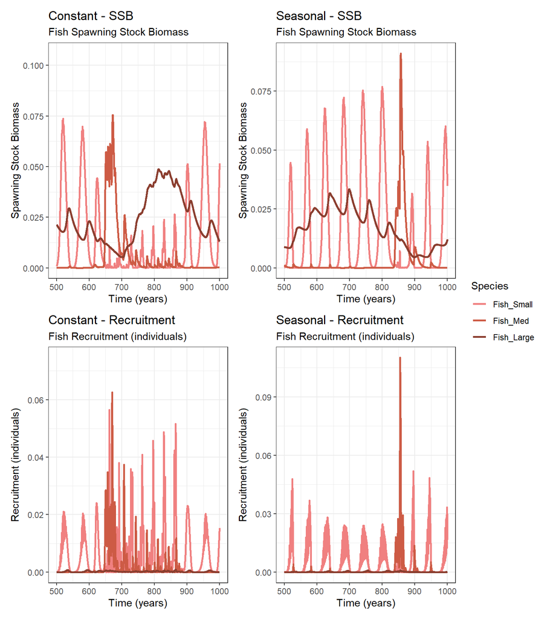

```r
# SSB comparison
p_ssb_const <- plotReproduction(mdl_constant, by = "SSB") +
  ggtitle("Constant - SSB") + xlim(500, 1000)

p_ssb_seas <- plotReproduction(mdl_seasonal, by = "SSB") +
  ggtitle("Seasonal - SSB") + xlim(500, 1000)

# Recruitment comparison
p_rec_const <- plotReproduction(mdl_constant, by = "recruitment") +
  ggtitle("Constant - Recruitment") + xlim(500, 1000)

p_rec_seas <- plotReproduction(mdl_seasonal, by = "recruitment") +
  ggtitle("Seasonal - Recruitment") + xlim(500, 1000)

wrap_plots(p_ssb_const, p_ssb_seas, p_rec_const, p_rec_seas,
           ncol = 2, guides = "collect")
```

### Stock-Recruitment: Constant vs Seasonal

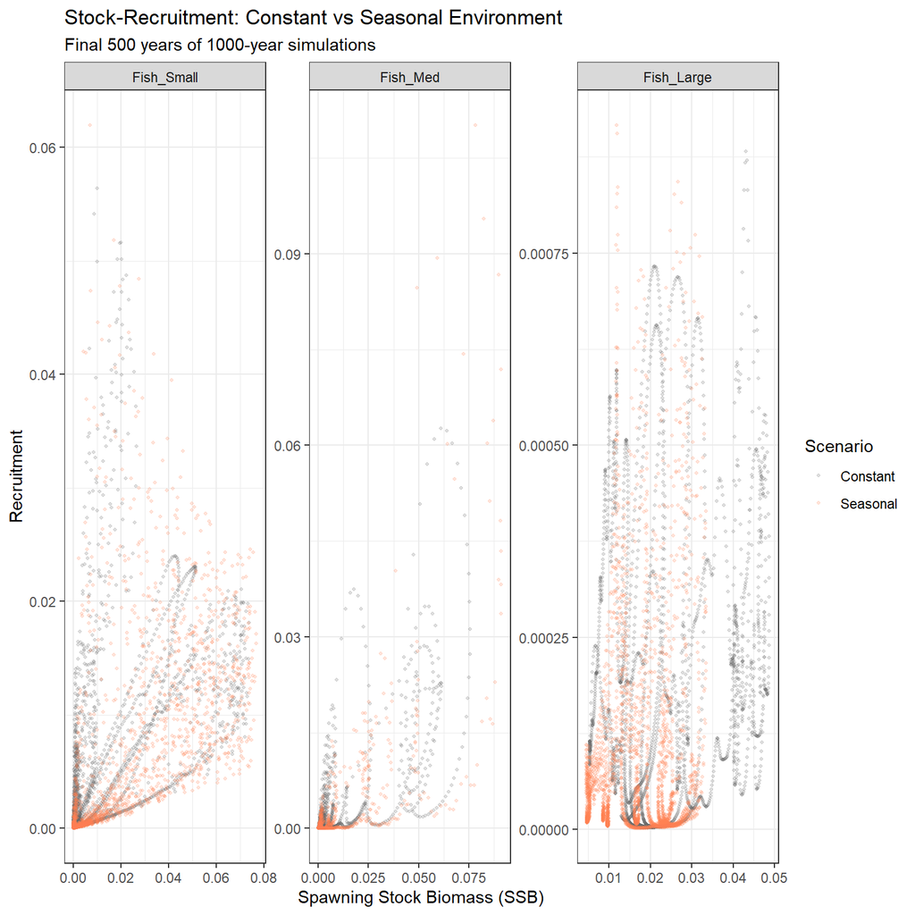

```r
# Build S-R data for both scenarios
build_sr_data <- function(mdl, scenario_name, n_years_avg = 500) {
  fish_grps <- mdl$param$fish_grps
  fish_names <- mdl$param$Groups$Species[fish_grps]
  n_save <- length(mdl$time)
  dt_save <- mdl$param$isave * mdl$param$dt
  n_avg <- min(n_save, round(n_years_avg / dt_save))
  start_idx <- max(1, n_save - n_avg + 1)

  sr <- data.frame()
  for (f in seq_along(fish_names)) {
    df <- data.frame(
      SSB = mdl$SSB[start_idx:n_save, f],
      Recruitment = mdl$recruitment[start_idx:n_save, f],
      Fish_Group = fish_names[f],
      Scenario = scenario_name
    )
    sr <- rbind(sr, df)
  }
  sr$Fish_Group <- factor(sr$Fish_Group, levels = fish_names)
  return(sr)
}

sr_const <- build_sr_data(mdl_constant, "Constant")
sr_seas <- build_sr_data(mdl_seasonal, "Seasonal")
sr_combined <- rbind(sr_const, sr_seas)

ggplot(sr_combined %>% filter(SSB > 0 & Recruitment > 0),
       aes(x = SSB, y = Recruitment, colour = Scenario)) +
  geom_point(alpha = 0.2, size = 0.8) +
  facet_wrap(~Fish_Group, scales = "free") +
  scale_colour_manual(values = c("Constant" = "grey40", "Seasonal" = "coral")) +
  theme_bw() +
  labs(x = "Spawning Stock Biomass (SSB)",
       y = "Recruitment",
       title = "Stock-Recruitment: Constant vs Seasonal Environment",
       subtitle = "Final 500 years of 1000-year simulations")
```

## Part 3: Exploring Chlorophyll Gradients

Let’s explore how productivity (chlorophyll concentration) affects reproduction metrics and community composition across a wide gradient from oligotrophic to eutrophic conditions. For the chlorophyll *a* gradient, a distribution of log<sub>10</sub>(Chlorophyll *a*) values were computed at 0.1 intervals between -1.7 and 0.5 log<sub>10</sub>(Chlorophyll *a*) (n = 23) and the mean proportion calculated for each of the bins. We run each scenario for 1000 years to ensure steady-state.

```r
# Chlorophyll gradient: log10(chl) from -1.7 to 0.5 at 0.1 intervals (n = 23)
log10_chl_seq <- seq(-1.7, 0.5, by = 0.1)
chl_levels <- 10^log10_chl_seq
```

### Multi-Temperature Chlorophyll Gradient Experiments

We run the chlorophyll gradient at three temperatures (10°C, 15°C, 20°C) to examine how temperature modulates the productivity response.

```r
# Load pre-computed models across chlorophyll gradient at multiple temperatures
# (69 models computed by run_gradient_models.R)
sst_variants <- c(10, 15, 20)

results_chl <- list()
for (temp in sst_variants) {
  temp_char <- as.character(temp)
  results_chl[[temp_char]] <- lapply(seq_along(chl_levels), function(i) {
    cache_name <- sprintf("mdl_chl_log10_%.1f_sst%d_1000yr", log10(chl_levels[i]), temp)
    cache_file <- file.path(cache_dir, paste0(cache_name, ".rds"))
    if (!file.exists(cache_file)) stop("Missing cache: ", cache_name,
      ". Run source('vignettes/run_gradient_models.R') first.")
    readRDS(cache_file)
  })
}
```

### Fish Biomass, SSB and Recruitment Across the Gradient

```r
# Extract fish metrics across chlorophyll gradient for all temperatures
num_fish <- 3
fish_names <- c("Fish_Small", "Fish_Med", "Fish_Large")

fish_summary_all <- data.frame()

for (temp in sst_variants) {
  temp_char <- as.character(temp)
  fish_grps <- results_chl[[temp_char]][[1]]$param$fish_grps

  for (i in seq_along(chl_levels)) {
    mdl <- results_chl[[temp_char]][[i]]
    final_idx <- length(mdl$time)

    # Average biomass over last 500 years
    avg_biomass <- averageTimeSeries(mdl, var = "biomass", n_years = 500)
    fish_biomass <- rowSums(avg_biomass[fish_grps, , drop = FALSE])

    for (f in 1:num_fish) {
      fish_summary_all <- rbind(fish_summary_all, data.frame(
        chl = chl_levels[i],
        sst = temp,
        fish_group = fish_names[f],
        final_biomass = fish_biomass[f],
        final_SSB = mdl$SSB[final_idx, f],
        final_recruitment = mdl$recruitment[final_idx, f]
      ))
    }
  }
}
```

[output not shown]

[output cut: 14 more lines]

[output not shown]

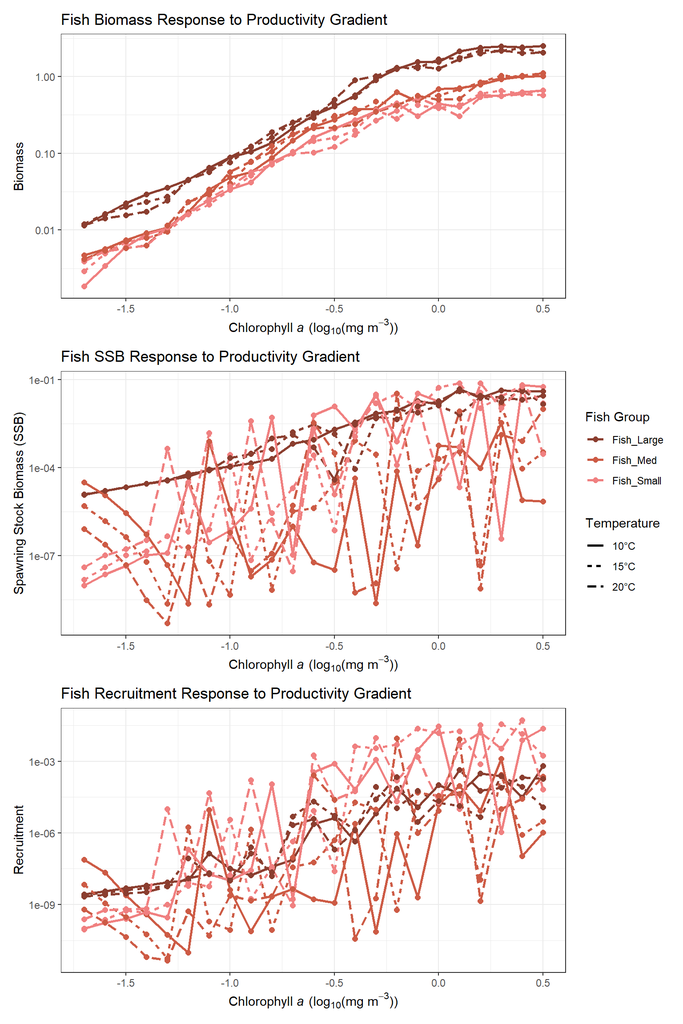

```r
fish_summary_all$sst_label <- paste0(fish_summary_all$sst, "\u00B0C")

# Get fish colours
fish_colours <- results_chl[["15"]][[1]]$param$Groups$PlotColour[
  results_chl[["15"]][[1]]$param$fish_grps]
names(fish_colours) <- fish_names

# Plot Fish Biomass vs chlorophyll across temperatures
p_biomass <- ggplot(fish_summary_all,
                    aes(x = log10(chl), y = final_biomass, colour = fish_group,
                        linetype = sst_label)) +
  geom_line(linewidth = 1) +
  geom_point(size = 2) +
  scale_y_log10() +
  scale_colour_manual(values = fish_colours) +
  theme_bw() +
  labs(x = expression("Chlorophyll " * italic(a) * " (log"[10] * "(mg m"^-3*"))"),
       y = "Biomass",
       title = "Fish Biomass Response to Productivity Gradient",
       colour = "Fish Group", linetype = "Temperature")

# SSB
p_ssb <- ggplot(fish_summary_all,
                aes(x = log10(chl), y = final_SSB, colour = fish_group,
                    linetype = sst_label)) +
  geom_line(linewidth = 1) +
  geom_point(size = 2) +
  scale_y_log10() +
  scale_colour_manual(values = fish_colours) +
  theme_bw() +
  labs(x = expression("Chlorophyll " * italic(a) * " (log"[10] * "(mg m"^-3*"))"),
       y = "Spawning Stock Biomass (SSB)",
       title = "Fish SSB Response to Productivity Gradient",
       colour = "Fish Group", linetype = "Temperature")

# Recruitment
p_recruit <- ggplot(fish_summary_all,
                    aes(x = log10(chl), y = final_recruitment, colour = fish_group,
                        linetype = sst_label)) +
  geom_line(linewidth = 1) +
  geom_point(size = 2) +
  scale_y_log10() +
  scale_colour_manual(values = fish_colours) +
  theme_bw() +
  labs(x = expression("Chlorophyll " * italic(a) * " (log"[10] * "(mg m"^-3*"))"),
       y = "Recruitment",
       title = "Fish Recruitment Response to Productivity Gradient",
       colour = "Fish Group", linetype = "Temperature")

wrap_plots(p_biomass, p_ssb, p_recruit, ncol = 1, guides = "collect")
```

### Stock-Recruitment Across the Chlorophyll Gradient

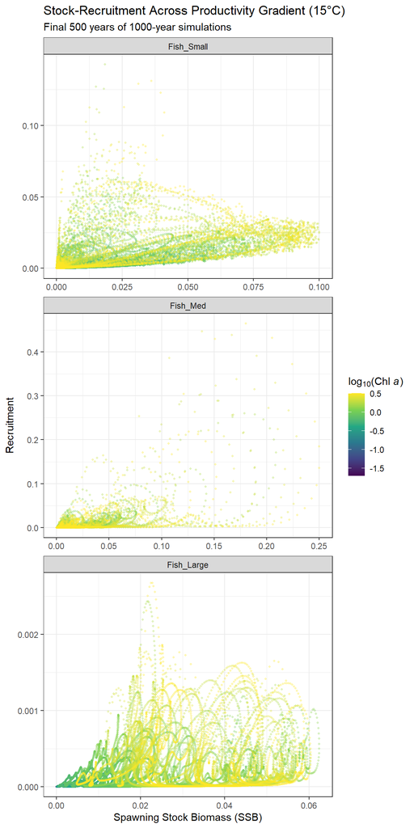

```r
# Build S-R data across chlorophyll gradient at 15°C
sr_chl_data <- data.frame()
for (i in seq_along(chl_levels)) {
  mdl <- results_chl[["15"]][[i]]
  sr_temp <- build_sr_data(mdl, paste0("Chl = ", round(chl_levels[i], 3), " mg/m³"), n_years_avg = 500)
  sr_temp$chl <- chl_levels[i]
  sr_chl_data <- rbind(sr_chl_data, sr_temp)
}

ggplot(sr_chl_data %>% filter(SSB > 0 & Recruitment > 0),
       aes(x = SSB, y = Recruitment, colour = log10(chl))) +
  geom_point(alpha = 0.3, size = 0.8) +
  facet_wrap(~Fish_Group, scales = "free", ncol = 1) +
  scale_colour_viridis_c(option = "viridis",
                         name = expression(log[10] * "(Chl " * italic(a) * ")")) +
  theme_bw() +
  labs(x = "Spawning Stock Biomass (SSB)",
       y = "Recruitment",
       title = "Stock-Recruitment Across Productivity Gradient (15\u00B0C)",
       subtitle = "Final 500 years of 1000-year simulations")
```

### Community Composition Across the Gradient

Let’s examine how community composition changes across the productivity gradient. Following Heneghan et al., we split the lower trophic levels into two panels: (1) phytoplankton size classes with flagellates and ciliates, and (2) the remaining zooplankton groups.

[output not shown]

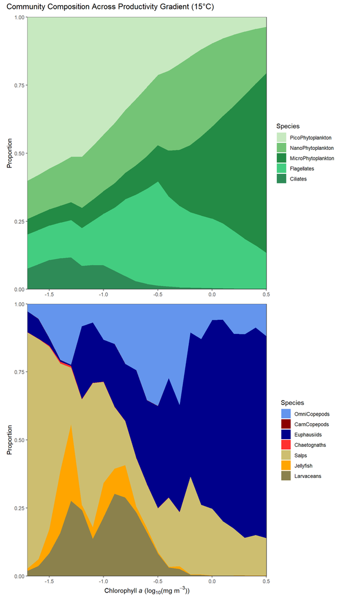

```r
# ============================================================================
# HELPER: Extract community composition with phytoplankton size classes
# ============================================================================
extract_community_composition <- function(results_list, chl_levels, Groups,
                                          n_years_avg = 500) {

  all_species <- Groups$Species
  ngrps <- length(all_species)

  # ---- Zooplankton/Fish biomass ----
  biomass_summary <- data.frame()
  for (i in seq_along(chl_levels)) {
    mdl <- results_list[[i]]
    avg_biomass <- averageTimeSeries(mdl, var = "biomass", n_years = n_years_avg)
    total_biomass <- rowSums(avg_biomass)

    for (g in 1:ngrps) {
      biomass_summary <- rbind(biomass_summary, data.frame(
        chl = chl_levels[i],
        species = all_species[g],
        biomass = total_biomass[g],
        type = Groups$Type[g]
      ))
    }
  }

  # ---- Phytoplankton size class biomass ----
  phyto_summary <- data.frame()
  for (i in seq_along(chl_levels)) {
    mdl <- results_list[[i]]
    # Use the phytoplankton parameters to calculate size class biomass
    env_row <- data.frame(chl = chl_levels[i])
    phyto_params <- calculatePhytoParam(env_row)

    phyto_summary <- rbind(phyto_summary, data.frame(
      chl = chl_levels[i],
      species = c("PicoPhytoplankton", "NanoPhytoplankton", "MicroPhytoplankton"),
      biomass = c(phyto_params$pico_biom, phyto_params$nano_biom, phyto_params$micro_biom),
      type = "Phytoplankton"
    ))
  }

  return(list(zoo_fish = biomass_summary, phyto = phyto_summary))
}

# ============================================================================
# HELPER: Create split-panel community composition plot
# ============================================================================
plot_split_community <- function(results_list, chl_levels, Groups,
                                 temperature_label, n_years_avg = 500) {

  comp <- extract_community_composition(results_list, chl_levels, Groups,
                                        n_years_avg = n_years_avg)

  # Get model colours
  plot_colours <- Groups$PlotColour
  names(plot_colours) <- Groups$Species

  # Add phytoplankton colours
  phyto_colours <- c(
    "PicoPhytoplankton" = "#c7e9c0",
    "NanoPhytoplankton" = "#74c476",
    "MicroPhytoplankton" = "#238b45"
  )

  # ---- PANEL 1: Phyto size classes + Flagellates + Ciliates ----
  upper_groups <- c("PicoPhytoplankton", "NanoPhytoplankton", "MicroPhytoplankton",
                    "Flagellates", "Ciliates")

  # Combine phyto and small zoo data
  flag_cil <- comp$zoo_fish %>%
    filter(species %in% c("Flagellates", "Ciliates"))
  upper_data <- rbind(comp$phyto, flag_cil)
  upper_data$species <- factor(upper_data$species, levels = upper_groups)

  # Calculate proportions within upper panel
  upper_data <- upper_data %>%
    group_by(chl) %>%
    mutate(proportion = biomass / sum(biomass, na.rm = TRUE)) %>%
    ungroup()

  upper_colours <- c(phyto_colours,
                     plot_colours[c("Flagellates", "Ciliates")])

  p_upper <- ggplot(upper_data,
                    aes(x = log10(chl), y = proportion, fill = species)) +
    geom_area(position = "stack") +
    scale_fill_manual(values = upper_colours, name = "Species") +
    scale_y_continuous(expand = c(0, 0)) +
    scale_x_continuous(expand = c(0, 0)) +
    theme_bw() +
    theme(axis.title.x = element_blank(),
          legend.position = "right") +
    labs(y = "Proportion")

  # ---- PANEL 2: Remaining zooplankton (no Flagellates, Ciliates, no Fish) ----
  lower_groups <- c("OmniCopepods", "CarnCopepods", "Euphausiids",
                    "Chaetognaths", "Salps", "Jellyfish", "Larvaceans")

  lower_data <- comp$zoo_fish %>%
    filter(species %in% lower_groups)
  lower_data$species <- factor(lower_data$species, levels = lower_groups)

  # Calculate proportions within lower panel
  lower_data <- lower_data %>%
    group_by(chl) %>%
    mutate(proportion = biomass / sum(biomass, na.rm = TRUE)) %>%
    ungroup()

  lower_colours <- plot_colours[lower_groups]

  p_lower <- ggplot(lower_data,
                    aes(x = log10(chl), y = proportion, fill = species)) +
    geom_area(position = "stack") +
    scale_fill_manual(values = lower_colours, name = "Species") +
    scale_y_continuous(expand = c(0, 0)) +
    scale_x_continuous(expand = c(0, 0)) +
    theme_bw() +
    theme(legend.position = "right") +
    labs(x = expression("Chlorophyll " * italic(a) * " (log"[10] * "(mg m"^-3*"))"),
         y = "Proportion")

  # Combine with title
  combined <- wrap_plots(p_upper, p_lower, ncol = 1) +
    plot_annotation(title = paste0("Community Composition Across Productivity Gradient (",
                                   temperature_label, ")"))

  return(combined)
}

# ---- Plot community composition at 15°C ----
plot_split_community(results_chl[["15"]], chl_levels, Groups,
                     "15\u00B0C", n_years_avg = 500)
```

[output not shown]

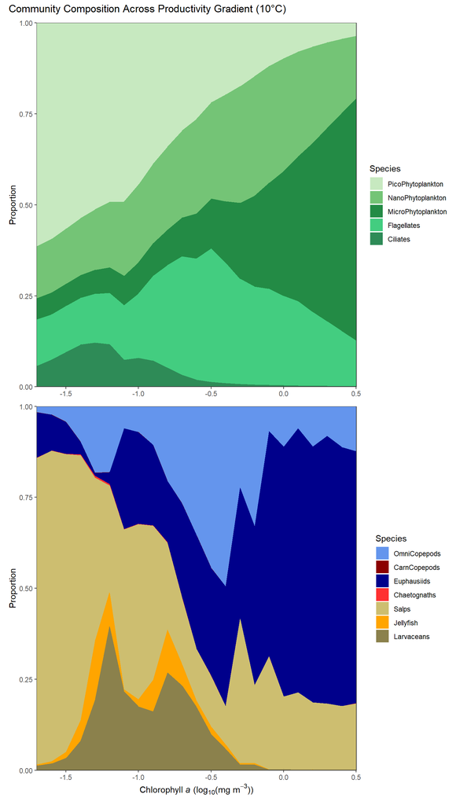

```r
# ---- Plot community composition at 10°C ----
plot_split_community(results_chl[["10"]], chl_levels, Groups,
                     "10\u00B0C", n_years_avg = 500)
```

[output not shown]

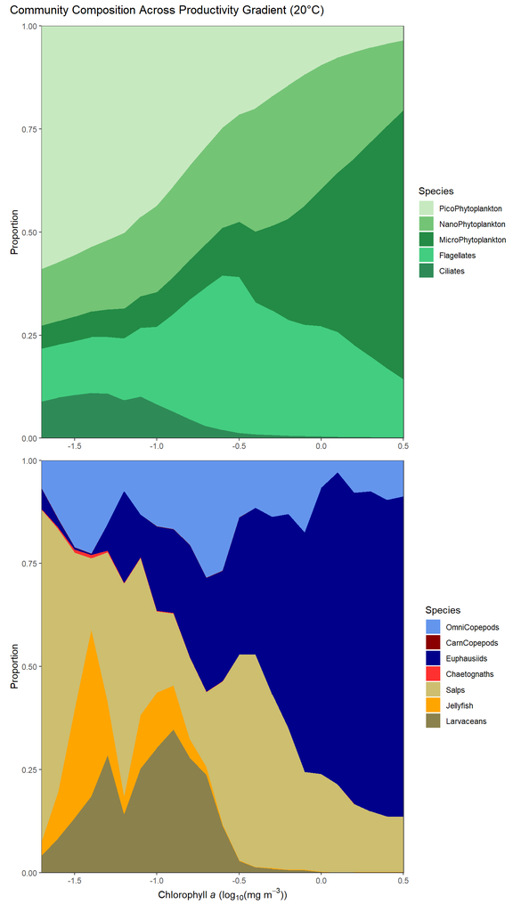

```r
# ---- Plot community composition at 20°C ----
plot_split_community(results_chl[["20"]], chl_levels, Groups,
                     "20\u00B0C", n_years_avg = 500)
```

### Full Community Composition (Including Fish)

For completeness, here is the full community composition including fish groups across the gradient at 15°C:

```r
# Standard full community composition plot (all groups)
all_species <- Groups$Species
ngrps <- length(all_species)
plot_colours <- Groups$PlotColour
names(plot_colours) <- all_species

biomass_full <- data.frame()
for (i in seq_along(chl_levels)) {
  mdl <- results_chl[["15"]][[i]]
  avg_biomass <- averageTimeSeries(mdl, var = "biomass", n_years = 500)
  total_biomass <- rowSums(avg_biomass)

  for (g in 1:ngrps) {
    biomass_full <- rbind(biomass_full, data.frame(
      chl = chl_levels[i],
      species = all_species[g],
      biomass = total_biomass[g],
      type = Groups$Type[g]
    ))
  }
}
```

[output not shown]

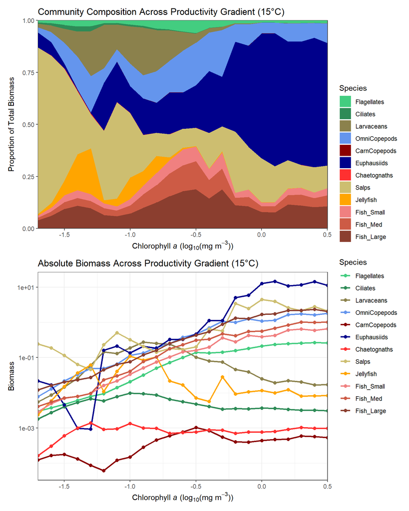

```r
biomass_full <- biomass_full %>%
  group_by(chl) %>%
  mutate(proportion = biomass / sum(biomass, na.rm = TRUE)) %>%
  ungroup()

biomass_full$species <- factor(biomass_full$species, levels = all_species)

# Proportion plot - using log10(chl) on x-axis to match other gradient plots
p_prop <- ggplot(biomass_full,
                 aes(x = log10(chl), y = proportion, fill = species)) +
  geom_area(position = "stack") +
  scale_fill_manual(values = plot_colours) +
  scale_y_continuous(expand = c(0, 0)) +
  scale_x_continuous(expand = c(0, 0)) +
  theme_bw() +
  labs(x = expression("Chlorophyll " * italic(a) * " (log"[10] * "(mg m"^-3*"))"),
       y = "Proportion of Total Biomass",
       title = "Community Composition Across Productivity Gradient (15\u00B0C)",
       fill = "Species")

# Absolute biomass
p_abs <- ggplot(biomass_full, aes(x = log10(chl), y = biomass, colour = species)) +
  geom_line(linewidth = 1) +
  geom_point(size = 2) +
  scale_y_log10() +
  scale_x_continuous(expand = c(0, 0)) +
  scale_colour_manual(values = plot_colours) +
  theme_bw() +
  labs(x = expression("Chlorophyll " * italic(a) * " (log"[10] * "(mg m"^-3*"))"),
       y = "Biomass",
       title = "Absolute Biomass Across Productivity Gradient (15\u00B0C)",
       colour = "Species")

wrap_plots(p_prop, p_abs, ncol = 1, guides = "collect")
```

## Part 4: Temperature Effects

Explore how temperature affects fish reproduction through metabolic scaling. We run 1000-year simulations at 1 mg m⁻³ chlorophyll across a temperature gradient.

```r
# Load pre-computed models across temperature gradient
# (5 models computed by run_gradient_models.R)
sst_levels <- c(5, 10, 15, 20, 25)

results_sst <- lapply(seq_along(sst_levels), function(i) {
  cache_name <- sprintf("mdl_sst%d_chl1_1000yr", sst_levels[i])
  cache_file <- file.path(cache_dir, paste0(cache_name, ".rds"))
  if (!file.exists(cache_file)) stop("Missing cache: ", cache_name,
    ". Run source('vignettes/run_gradient_models.R') first.")
  readRDS(cache_file)
})
```

### Fish Biomass, SSB and Recruitment Across the Temperature Gradient

```r
# Extract fish metrics across temperature gradient
fish_sst_summary <- data.frame()

for (i in seq_along(sst_levels)) {
  mdl <- results_sst[[i]]
  final_idx <- length(mdl$time)
  fish_grps <- mdl$param$fish_grps

  avg_biomass <- averageTimeSeries(mdl, var = "biomass", n_years = 500)
  fish_biomass <- rowSums(avg_biomass[fish_grps, , drop = FALSE])

  for (f in 1:num_fish) {
    fish_sst_summary <- rbind(fish_sst_summary, data.frame(
      sst = sst_levels[i],
      fish_group = fish_names[f],
      final_biomass = fish_biomass[f],
      final_SSB = mdl$SSB[final_idx, f],
      final_recruitment = mdl$recruitment[final_idx, f]
    ))
  }
}
```

```
#> Averaging final 500 years (2500 saved time steps with isave = 2) of biomass from 5000 total saved time steps.
#> Averaging final 500 years (2500 saved time steps with isave = 2) of biomass from 5000 total saved time steps.
#> Averaging final 500 years (2500 saved time steps with isave = 2) of biomass from 5000 total saved time steps.
#> Averaging final 500 years (2500 saved time steps with isave = 2) of biomass from 5000 total saved time steps.
#> Averaging final 500 years (2500 saved time steps with isave = 2) of biomass from 5000 total saved time steps.
```

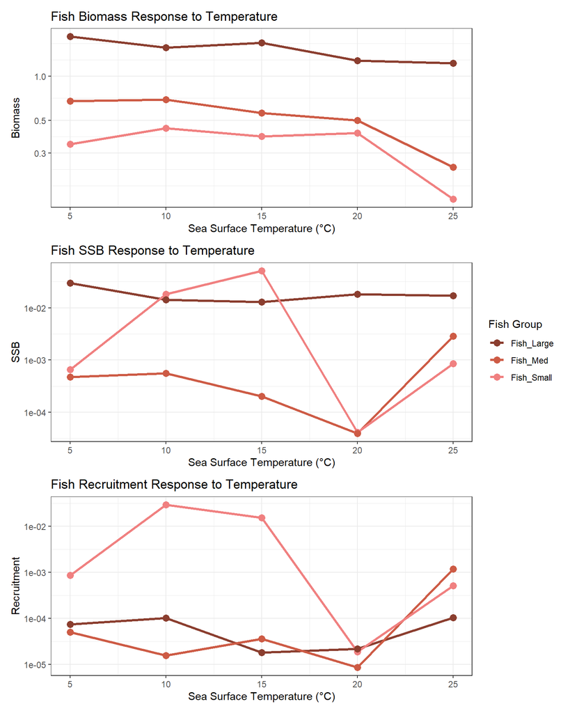

```r
# Biomass vs temperature
p_biomass <- ggplot(fish_sst_summary,
                    aes(x = sst, y = final_biomass, colour = fish_group)) +
  geom_line(linewidth = 1.2) + geom_point(size = 3) +
  scale_y_log10() +
  scale_colour_manual(values = fish_colours) +
  theme_bw() +
  labs(x = "Sea Surface Temperature (\u00B0C)", y = "Biomass",
       title = "Fish Biomass Response to Temperature", colour = "Fish Group")

# SSB vs temperature
p_ssb <- ggplot(fish_sst_summary,
                aes(x = sst, y = final_SSB, colour = fish_group)) +
  geom_line(linewidth = 1.2) + geom_point(size = 3) +
  scale_y_log10() +
  scale_colour_manual(values = fish_colours) +
  theme_bw() +
  labs(x = "Sea Surface Temperature (\u00B0C)", y = "SSB",
       title = "Fish SSB Response to Temperature", colour = "Fish Group")

# Recruitment vs temperature
p_recruit <- ggplot(fish_sst_summary,
                    aes(x = sst, y = final_recruitment, colour = fish_group)) +
  geom_line(linewidth = 1.2) + geom_point(size = 3) +
  scale_y_log10() +
  scale_colour_manual(values = fish_colours) +
  theme_bw() +
  labs(x = "Sea Surface Temperature (\u00B0C)", y = "Recruitment",
       title = "Fish Recruitment Response to Temperature", colour = "Fish Group")

wrap_plots(p_biomass, p_ssb, p_recruit, ncol = 1, guides = "collect")
```

### Stock-Recruitment Across the Temperature Gradient

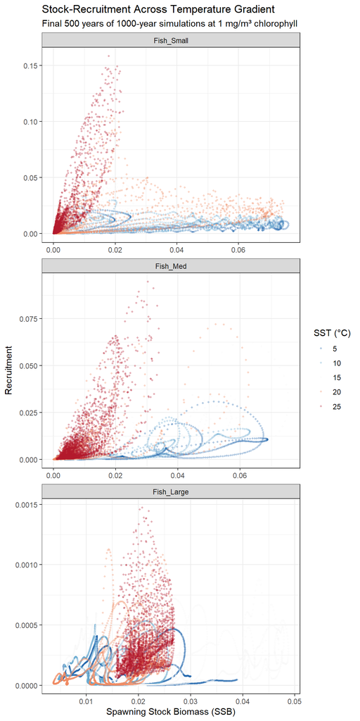

```r
# S-R relationships across temperature gradient
sr_sst_data <- data.frame()
for (i in seq_along(sst_levels)) {
  sr_temp <- build_sr_data(results_sst[[i]],
                           paste0(sst_levels[i], "\u00B0C"),
                           n_years_avg = 500)
  sr_temp$sst <- sst_levels[i]
  sr_sst_data <- rbind(sr_sst_data, sr_temp)
}

ggplot(sr_sst_data %>% filter(SSB > 0 & Recruitment > 0),
       aes(x = SSB, y = Recruitment, colour = factor(sst))) +
  geom_point(alpha = 0.3, size = 0.8) +
  facet_wrap(~Fish_Group, scales = "free", ncol = 1) +
  scale_colour_manual(
    values = c("5" = "#2166ac", "10" = "#67a9cf", "15" = "#f7f7f7",
               "20" = "#ef8a62", "25" = "#b2182b"),
    name = "SST (\u00B0C)"
  ) +
  theme_bw() +
  labs(x = "Spawning Stock Biomass (SSB)",
       y = "Recruitment",
       title = "Stock-Recruitment Across Temperature Gradient",
       subtitle = "Final 500 years of 1000-year simulations at 1 mg/m\u00B3 chlorophyll")
```

### Community Composition Across the Temperature Gradient

```r
# Community composition across temperature gradient
biomass_sst <- data.frame()
for (i in seq_along(sst_levels)) {
  mdl <- results_sst[[i]]
  avg_biomass <- averageTimeSeries(mdl, var = "biomass", n_years = 500)
  total_biomass <- rowSums(avg_biomass)

  for (g in 1:ngrps) {
    biomass_sst <- rbind(biomass_sst, data.frame(
      sst = sst_levels[i],
      species = all_species[g],
      biomass = total_biomass[g],
      type = Groups$Type[g]
    ))
  }
}
```

```
#> Averaging final 500 years (2500 saved time steps with isave = 2) of biomass from 5000 total saved time steps.
#> Averaging final 500 years (2500 saved time steps with isave = 2) of biomass from 5000 total saved time steps.
#> Averaging final 500 years (2500 saved time steps with isave = 2) of biomass from 5000 total saved time steps.
#> Averaging final 500 years (2500 saved time steps with isave = 2) of biomass from 5000 total saved time steps.
#> Averaging final 500 years (2500 saved time steps with isave = 2) of biomass from 5000 total saved time steps.
```

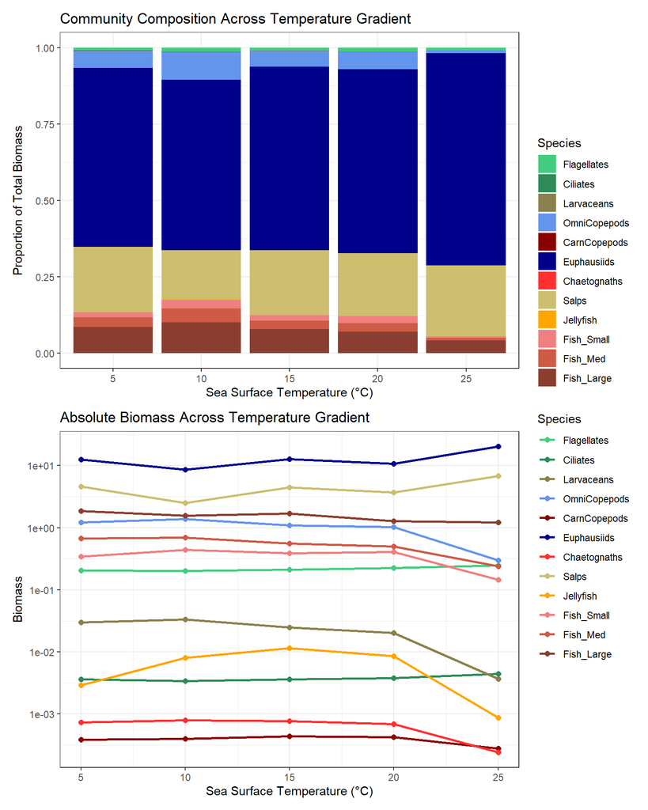

```r
biomass_sst <- biomass_sst %>%
  group_by(sst) %>%
  mutate(proportion = biomass / sum(biomass, na.rm = TRUE)) %>%
  ungroup()

biomass_sst$species <- factor(biomass_sst$species, levels = all_species)

# Proportion plot
p_prop <- ggplot(biomass_sst, aes(x = factor(sst), y = proportion, fill = species)) +
  geom_bar(stat = "identity", position = "stack") +
  scale_fill_manual(values = plot_colours) +
  theme_bw() +
  labs(x = "Sea Surface Temperature (\u00B0C)",
       y = "Proportion of Total Biomass",
       title = "Community Composition Across Temperature Gradient",
       fill = "Species")

# Absolute biomass
p_abs <- ggplot(biomass_sst, aes(x = sst, y = biomass, colour = species)) +
  geom_line(linewidth = 1) + geom_point(size = 2) +
  scale_y_log10() +
  scale_colour_manual(values = plot_colours) +
  theme_bw() +
  labs(x = "Sea Surface Temperature (\u00B0C)",
       y = "Biomass",
       title = "Absolute Biomass Across Temperature Gradient",
       colour = "Species")

wrap_plots(p_prop, p_abs, ncol = 1, guides = "collect")
```

## Summary

This vignette demonstrated the explicit energy budget and fish reproduction system in ZooMSS:

1. **Energy Budget Components**: The model now explicitly tracks defecation, metabolism, growth, and reproduction fractions
2. **Prey Quality Effects**: Defecation varies continuously with prey Carbon content - high-Carbon prey (like ciliates) have low defecation (~30%) while low-Carbon prey (like jellyfish) have high defecation (~50%)
3. **Fish Reproduction**: Fish groups allocate a fraction of assimilated energy (R_frac = 0.14) to reproduction, scaled by a maturity ogive
4. **Recruitment**: New fish enter the population through explicit recruitment based on Spawning Stock Biomass (SSB)
5. **Stock-Recruitment Relationships**: Emergent S-R dynamics arise from the energy budget, with characteristic patterns that vary across environmental gradients
6. **Environmental Sensitivity**: Reproduction metrics respond to:
   - Productivity (chlorophyll concentration)
   - Temperature (through metabolic scaling)
   - Seasonal cycles in environmental conditions

### Key Differences from Zooplankton

| Aspect | Zooplankton | Fish |
| --- | --- | --- |
| K_growth | 0.50 | 0.36 |
| R_frac | 0.00 | 0.14 |
| repro_on | 0 (disabled) | 1 (enabled) |
| Recruitment | Boundary condition | SSB-driven |

The explicit energy budget provides a mechanistic foundation for understanding how environmental change affects fish population dynamics through reproduction.